# Rapport des loyer à Paris

Luca Figlie, Hugo Saulig, Valentin Blanc, Torset Mael

2025-11-18

# Introduction

Ce rapport accompagne l’application Shiny fournie. Il décrit le jeu de données, les démarches statistiques effectuées et présente les graphiques importants de notre application selon la zone, le type de logement, le nombre de pièces et l’époque de construction. On propose enfin des conclusions potentielles et des limites.

# Jeu de donnée

Notre jeu de donnée porte sur les loyers de Paris. On a décidé de renommer les variables du jeu de donnée pour qu’elle soit plus facile à comprendre.

### Explication du jeu de donnée :

- Zone : indique le périmètre géographique dans lequel se situe le logement(plus de précision dans l’onglet définition de l’application).
- Type : décrit le type de logement (appartement, maison, logement collectif, etc.).
- Pieces : donne le nombre de pièces principales du logement.
- Epoque_Construction : renseigne la période de construction du bâtiment.
- Loyer_m2_Q1, Loyer_m2_Mediane, Loyer_m2_Q3, Loyer_m2_Moyenne : indique respectivement le premier quartile, la médiane, le troisième quartille et la moyenne du loyer au m².
- Loyer_Total_Q1, Loyer_Total_Mediane, Loyer_Total_Q3, Loyer_Total_Moyenne : indique respectivement le premier quartile, la médiane, le troisième quartille et la moyenne du loyer total.
- obs : nombre d’observations ayant servi à calculer les statistiques de la ligne.

# Démarches statistiques

Les objectifs principaux sont :

- Fournir des statistiques par zone, par nombre de pièce, par type de logement et par époque de construction.
- Montrer la différence de loyer selon les zones.
- Produire des classements (top 10 plus chères / moins chères).
- Visualiser la distribution des loyers (médiane avec premier et troisième quartille).
- Mesurer la dispersion des loyers via l’écart interquartile.
- Montrer les logements selon notre budget.
- Montrer le nombre de pièce par zone.

# Graphiques

## Loyers moyens par zone

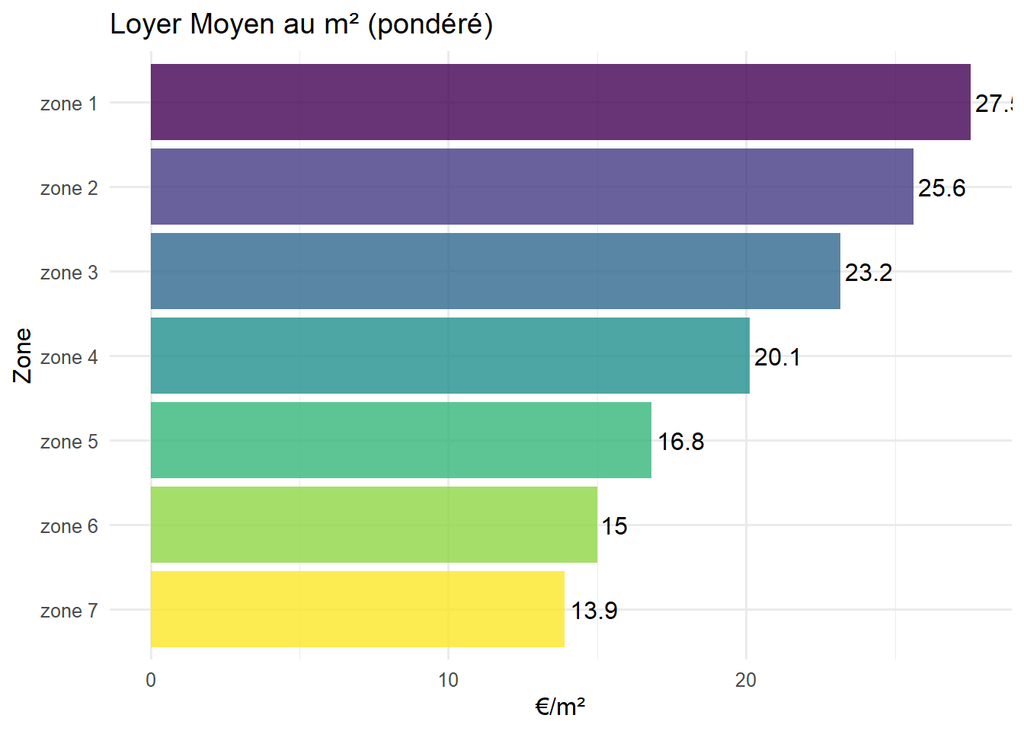

On remarque qu’en moyenne plus on est proche du centre plus les loyers sont élevés et inversement.

## Classements

#### Top 10 des configurations (zone/type/nb de pièces/date) les plus chères

| Config | Loyer_m2_Mediane | obs |
| --- | --- | --- |
| zone 2 / ensemble / 1P / avant 46 | 32.7 | 344 |
| zone 2 / appart / 1P / avant 46 | 32.7 | 344 |
| zone 1 / ensemble / 1P / (Non spécifié) | 32.2 | 155 |
| zone 1 / ensemble / 1P / avant 46 | 32.2 | 92 |
| zone 1 / appart / 1P / (Non spécifié) | 32.2 | 155 |
| zone 1 / appart / 1P / avant 46 | 32.2 | 92 |
| zone 2 / ensemble / 1P / (Non spécifié) | 31.9 | 102 |
| zone 2 / ensemble / 1P / (Non spécifié) | 30.4 | 781 |
| zone 2 / appart / 1P / (Non spécifié) | 30.4 | 781 |
| zone 1 / ensemble / 2P / avant 46 | 29.3 | 90 |

#### Top 10 des configurations (zone/type/nb de pièces/date) les moins chères

| Config | Loyer_m2_Mediane | obs |
| --- | --- | --- |
| zone 6 / appart / 4P+ / 46-70 | 10.6 | 66 |
| zone 6 / ensemble / 4P+ / 46-70 | 11.4 | 81 |
| zone 5 / appart / 4P+ / 46-70 | 11.9 | 109 |
| zone 6 / ensemble / 4P+ / 71-90 | 11.9 | 77 |
| zone 5 / ensemble / 4P+ / 71-90 | 12.0 | 87 |
| zone 5 / appart / 4P+ / 71-90 | 12.0 | 76 |
| zone 6 / appart / 4P+ / 71-90 | 12.1 | 54 |
| zone 6 / ensemble / 4P+ / (Non spécifié) | 12.3 | 268 |
| zone 6 / appart / 4P+ / (Non spécifié) | 12.3 | 192 |
| zone 6 / appart / 3P / 46-70 | 12.5 | 160 |

On remarque qu’en plus de la zone, le nombre de pièce influe sur le prix du mètre carré : les studios ont tendance à avoir un prix au mètre carré plus élevé que que les logements avec plus de 4 pièces. Ce genre de classement est plus intéressant avec des filtres plus sélectifs.

## Distribution (Médiane avec Q1 et Q3)

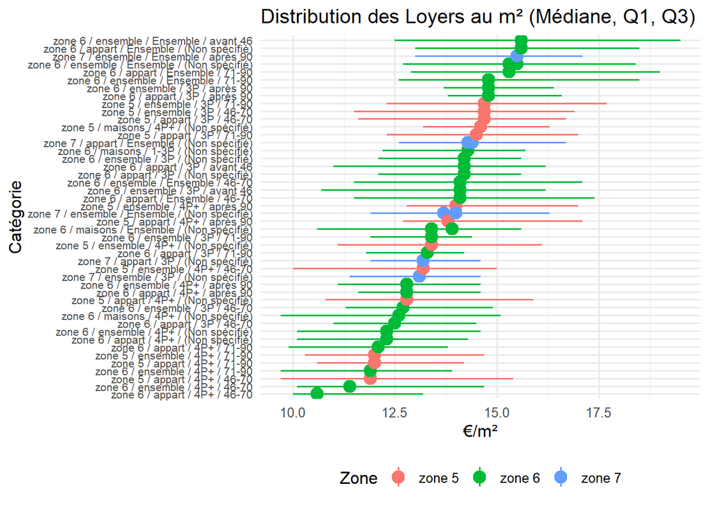

Seules les zones 5 à 7 ont été conservé pour des questions de lisibilité, plus une catégorie est basse sur l’axe des ordonées plus son loyer au m² médian est faible

## Dispersion — Écart interquartile moyen par zone

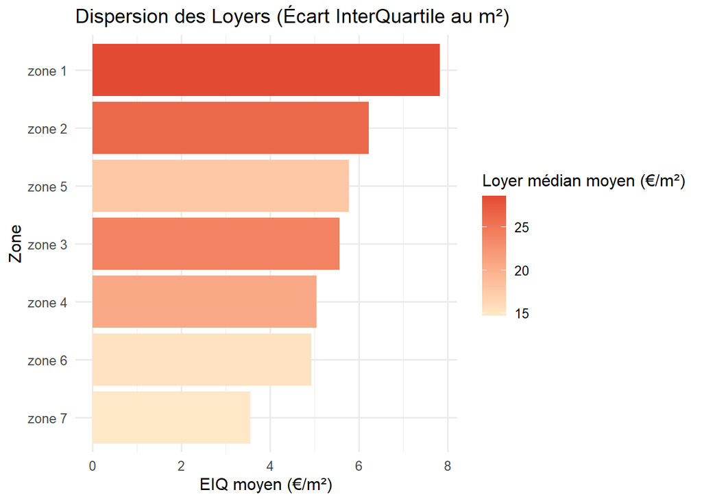

Graphique représentant la dispersion moyenne des loyers par zone On remarque que les zones proches du centre ont une dispersion des loyers plus élevée.

## Répartition des pièces par zone

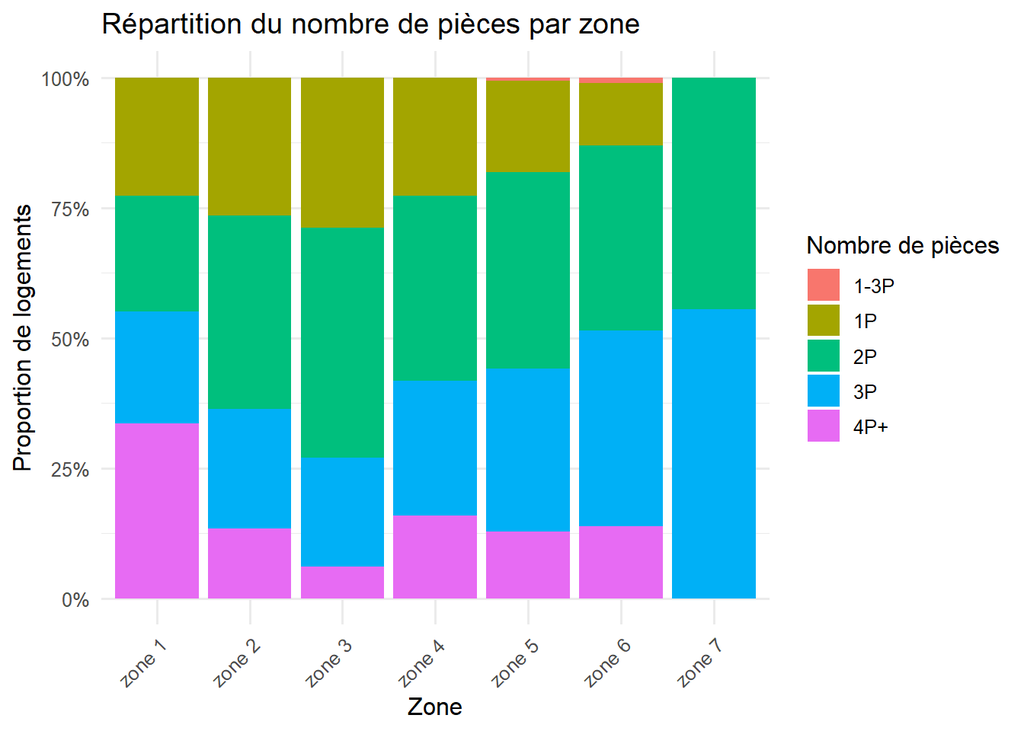

On remarque que dans la plupart des zones (si on ignore les Non spécifié) la proportion de logements la plus importante sont les 2 pièces. Cependant dans la zone 1 on remarque la présence conséquente de 4 pièces et plus.

# Conclusions

- **Tendances observées** : On s’attend à retrouver des loyers beaucoup plus élevés dans la Zone 1 et 2 (Paris centre et communes très proches) et des loyers décroissants vers les zones plus éloignées. Les graphiques (médiane et moyenne pondérée) permettent de visualiser cet écart. Les zones proches du centre montrent souvent une dispersion (EIQ) élevée c’est à dire qui il y a un mix entre logements très chers et logements moins chers même dans ces zones. La proportion de type de logement les plus présent sont les 2 pièces dans la plupart des zones. Enfin les studios ont un prix du mètres carré plus élevé que les 4 pièces et plus, ce qui doit être due aux nombreuses cellules vide de ces catégories dans le dataset
- **Limites** :
  - Présence de NA pour plusieurs métriques.
  - Le poids `obs` peut introduire un biais si certains ensembles sont sur-représentés ou sous représentés.